# ETC5512: Solutions for Lab 6

# Exercise 4: Practicing liner regression to understand the relationship between hard coral cover and algae abundance.

- Using the data that you created in Exercise 3 (wide format data).
- Run a linear regression model to understand the relationship between hard coral cover and algae.
- Add two new variables into the data set to store your predicted and residuals values from the regression.

```r
reg = lm(Algae ~ `Hard Coral`, data = regdataWF )
```

```r
regdataWF$predicted <- predict(reg)
regdataWF$residuals <- residuals(reg)
```

- Create the following figure and change the colours:

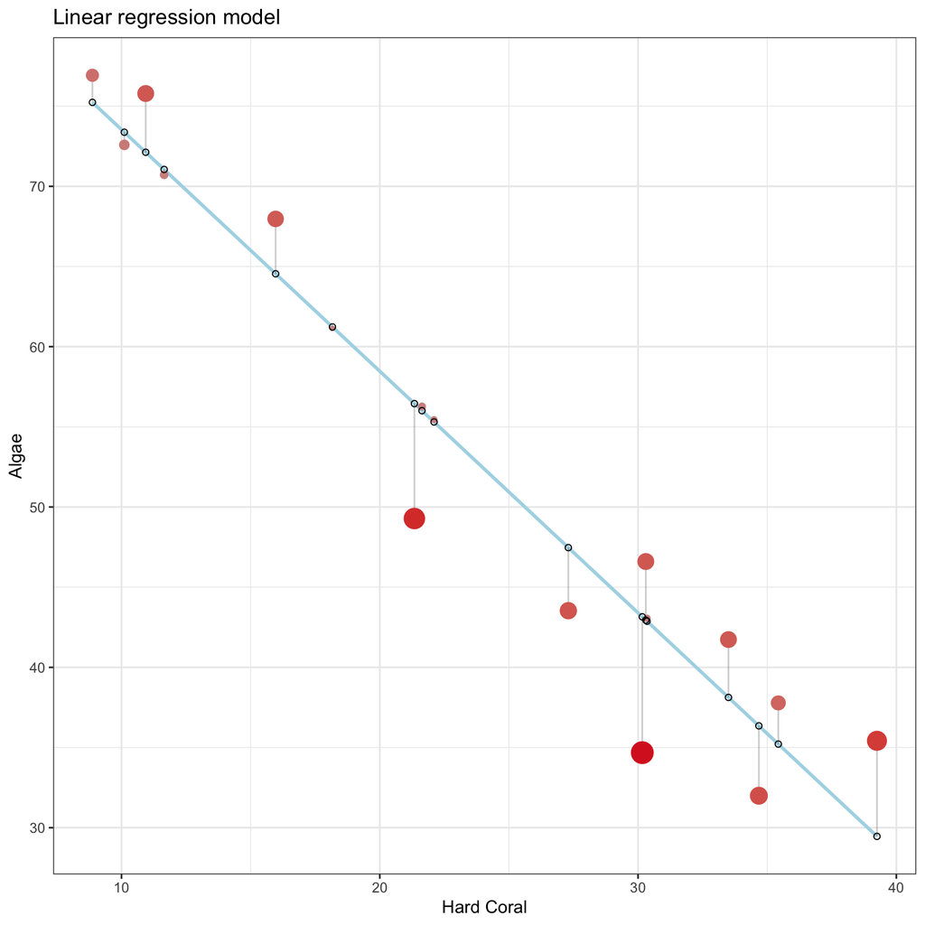

```r
ggplot(regdataWF, aes(x = `Hard Coral`, y = Algae)) +
  geom_smooth(method = "lm", se = FALSE, color = "lightblue") +
  geom_segment(aes(xend = `Hard Coral`, yend = predicted), alpha = .2) +
  geom_point(aes(color = abs(residuals), size = abs(residuals))) +
  scale_color_continuous(low = "#D19494", high = "#D92626") +
  guides(color = FALSE, size = FALSE) +  # Size legend also removed
  geom_point(aes(y = predicted), shape = 1) +
  theme_bw() +
  ggtitle("Linear regression model")
```